# Logistic Regression in Breast Cancer Patients

Carmen Canedo

11 August 2020

# Objective

We will be looking at data collected on breast cancer patients in Wisconsin by Dr. William H. Wolberg from 1989-1991. The data observes the growths in 699 individuals, measuring variables such as clump thickness, size uniformity, marginal adhesion, cell size, bare nuclei, bland chromatin, normal nucleoli, mitoses, and growth classification. In this report, I will be using a backwards selection process to create a logistic model to determine what explanatory variables most affect a benign or malignant diagnosis.

# Loading necessary libraries

These are the necessary libraries you will need to have loaded to follow along with the code below.

```r
library(tidyverse)
library(corrplot)
library(aod)
```

# Loading in data

The data provided to me by Professor Kongoli of American University was initially provided as an Excel document. You will need to convert the file to a .csv to read it into R.

```r
# Reading in .csv
breast_cancer_original <- read.csv("Breast_cancer_data_Wisconsin_Stat302_2020.csv")
```

## Cleaning data

Before beginning the analysis, I will make some adjustments to the data. I am renaming the columns for clarity, changing their class, and modifying the values of the growth classification.

```r
# Saving renamed columns into new data frame
breast_cancer <- breast_cancer_original %>%
  rename(clump_thickness = ClumpThick) %>%
  rename(size_uniformity = SizeUniforrm) %>%
  rename(shape_uniformity = shapeUniform) %>%
  rename(marginal_adhesion = Adhesion) %>%
  rename(cell_size = cell.cize) %>%
  rename(bare_nuclei = bareNuclei) %>%
  rename(bland_cromatin = Cromatin) %>%
  rename(normal_nucleoli = normalNuclei) %>%
  rename(mitoses = Mitozis) %>%
  rename(growth_class = Btype)
```

Normally, we would need to covert growth_class to a factor because its two values, 2 and 4, represent benign and malignant growths respectively. However, later in the code the `cor()` function requires that all columns are numeric. We will make those changes now, but it is imperative to keep in mind that calculations should not be done on these values.

```r
# Checking class
sapply(breast_cancer, class)

# List of column names
names <- c("ID", "clump_thickness", "size_uniformity", "shape_uniformity", "marginal_adhesion", "cell_size", "bare_nuclei", "bland_cromatin", "normal_nucleoli", "mitoses", "growth_class")

# Changing type to numeric using sapply and list of column names
breast_cancer[names] <- sapply(breast_cancer[names], as.numeric)

# Checking to make sure answer is correct
sapply(breast_cancer, class)
```

Lastly, we need to re-code 2 and 4 to 0 and 1, so that the program will be able to run its regression on the data.

```r
# Chaing to 0 and 1
breast_cancer <- breast_cancer  %>%
  mutate(growth = case_when(growth_class == 2 ~ 0, growth_class == 4 ~ 1)) %>%
  select(-growth_class) %>%
  rename(growth_class = growth)
```

# Analysis

## Correlation

Let’s take a look at the correlation matrix to get a general idea of the patterns in the data.

```r
# Computing correlation for breast_cancer data set
bc_correlations <- cor(breast_cancer)

# Calling object
bc_correlations

# Getting rid of missing values and ID
bc_corr <- breast_cancer %>%
  select(-bare_nuclei, -ID)

# Final correlation matrix
bc_corr <- cor(bc_corr)
bc_corr
```

```r
# Visualizing correlation matrix
corrplot.mixed(bc_corr,
         order = "hclust",
         tl.cex = .4,
         tl.col = "black")
```

[output not shown]

## Interpretation

- Size uniformity and cell size: 0.75
- Bland chromatin and growth classification: 0.76
- Bland chromatin and size uniformity: 0.76
- Growth classification and size uniformity: 0.82
- Growth classification and shape uniformity: 0.82
- Size uniformity and shape uniformity: 0.91

## Logistic model

We are going to use the backwards method to create our logistic model. We will first start with all potential explanatory variables and perform regression on them.

```r
# Creating model using all variables to determining growth_class
logistic_1 <- glm(growth_class ~ ., data = breast_cancer, family = "binomial")

# Results of logistic model
summary(logistic_1)
```

```
Call:
glm(formula = growth_class ~ ., family = "binomial", data = breast_cancer)

Deviance Residuals:
    Min       1Q   Median       3Q      Max
-3.4877  -0.1156  -0.0613   0.0223   2.4668

Coefficients:
                    Estimate Std. Error z value Pr(>|z|)
(Intercept)       -1.015e+01  1.454e+00  -6.983 2.89e-12 ***
ID                 4.008e-08  7.331e-07   0.055 0.956396
clump_thickness    5.349e-01  1.420e-01   3.767 0.000165 ***
size_uniformity   -6.818e-03  2.091e-01  -0.033 0.973995
shape_uniformity   3.234e-01  2.307e-01   1.402 0.161010
marginal_adhesion  3.306e-01  1.234e-01   2.679 0.007389 **
cell_size          9.624e-02  1.567e-01   0.614 0.539233
bare_nuclei        3.840e-01  9.546e-02   4.022 5.77e-05 ***
bland_cromatin     4.477e-01  1.716e-01   2.608 0.009099 **
normal_nucleoli    2.134e-01  1.131e-01   1.887 0.059224 .
mitoses            5.344e-01  3.294e-01   1.622 0.104740
---
Signif. codes:  0 ‘***’ 0.001 ‘**’ 0.01 ‘*’ 0.05 ‘.’ 0.1 ‘ ’ 1

(Dispersion parameter for binomial family taken to be 1)

    Null deviance: 884.35  on 682  degrees of freedom
Residual deviance: 102.89  on 672  degrees of freedom
  (16 observations deleted due to missingness)
AIC: 124.89

Number of Fisher Scoring iterations: 8
```

```r
# Wald Test
#anova(logistic_2, update(logistic_2, ~1), test = "Chisq")
wald.test(b = coef(logistic_2), Sigma = vcov(logistic_2), Terms = 3:4)
```

[output not shown]

```
Wald test:
----------

Chi-squared test:
X2 = 48.9, df = 2, P(> X2) = 2.4e-11
```

## Interpretation

Using the information above, we can infer which variables have an effect on whether breast cancer patients in Wisconsin are likely to have benign versus malignant growths.

The values on the y-axis of logistic regression are limited from 0 to 1 in order to calculate the probability. We can transform this to the log odds of cancerous growth to increase the domain of the y-axis from negative infinity to positive infinity. We will later visualize the logistic model using a domain of 0 to 1, but the coefficients are determined using logg odds.

# Graphing

In order to graph the probabilities of the model above, we need to create a new data frame that has the probabilities.

```r
# Creating new data frame of probabilities
predicted_data <- data.frame(probability_of_growth_class = logistic_2[["fitted.values"]], growth_class = logistic_2$data)
```

[output not shown]

[output not shown]

## Creating graph

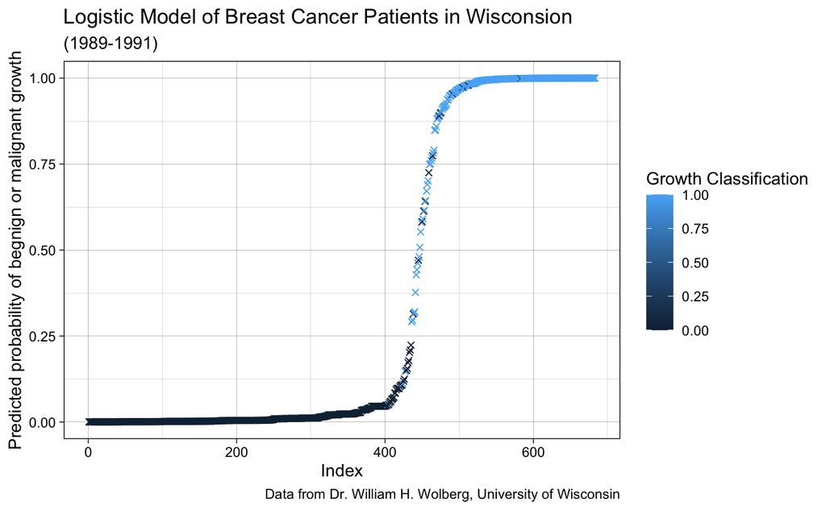

# Conclusion

Now that we have performed our logistic regression, we can see that clump thickness, marginal adhesion, bare nuclei, and bland chromatin have the greatest effect on the outcome of a benign or malignant diagnosis.